# MA611 Assignment 4

Ignacio Carracedo

October 22nd, 2016

## Monthly log returns of CRSP equal-weighted index (Jan 1962 - Dec 1999)

First, we plot the log returns of CRSP equal-weighted index over time:

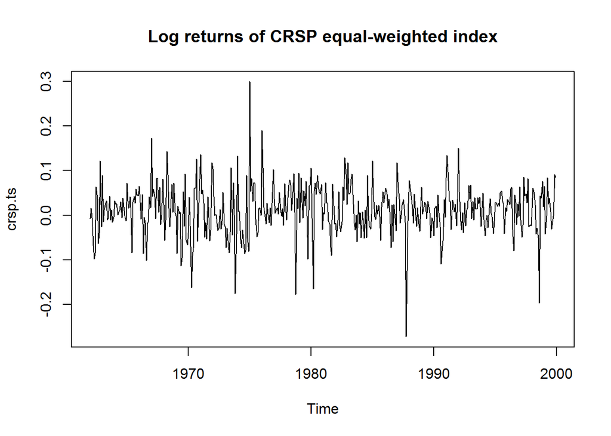

The first impression is that we have a weak stationary time series (constant mean and constant variance)

**1.a Obtain the summary statistics (sample mean, standard deviation, skewness, kurtosis, minimum, maximum). Are the log returns skewed? Do they have heavy tails? Use a 5% significance level to answer the questions**

We get a better sense of the data by checking the summary statistics:

```
##     Min.  1st Qu.   Median     Mean  3rd Qu.     Max.
## -0.27230 -0.01813  0.01465  0.01219  0.04343  0.29920
```

```
##   Start Size       Mean Standard.Deviation   Skewness Excess.Kurtosis
## 1  1962  456 0.01219048         0.05593551 -0.2170941        3.358326
##   Minimum Maximum
## 1 -0.2723 0.29921
```

The data is negatively skewed, the left tail is a little longer that the right tail, but the value is very close to 0 so we can say that the distribution is approximately symmetric.

Let’s test now if we have enough evidence to say that the mean is different than 0. We get the z-score and calculate p-value under the assumption of normal distribution.We use hypothesis testing with null hypothesis that mean is 0:

```
## [1] 1.628686e-06
```

With the p-value from above and significance level at 0.05 we reject the null hypothesis and conclude that the mean is different from 0.

**1.b. Discuss whether you believe that the series is weakly stationary or not?**

As we previously mentioned, we consider the series as weakly stationary. Even though there are a few outliers we can say that the mean is constant (no visible trend) and also that the variance is constant throughout the series (homoscedasticity)

**1.c. Build an AR(1) model for the log returns and check the model**

Now that we assume the data as weakly stationary we can fit a AR(1) model:

```
##
## Call:
## arima(x = crsp.ts, order = c(1, 0, 0))
##
## Coefficients:
##          ar1  intercept
##       0.2243     0.0122
## s.e.  0.0457     0.0033
##
## sigma^2 estimated as 0.002965:  log likelihood = 680.12,  aic = -1354.23
```

We get the following model: **xt - 0.2243 xt-1 = 0.0122(1-0.2243) + at**. The small value of the sigma^2 indicates a good fit, but to be sure let’s check some diagnostic plots:

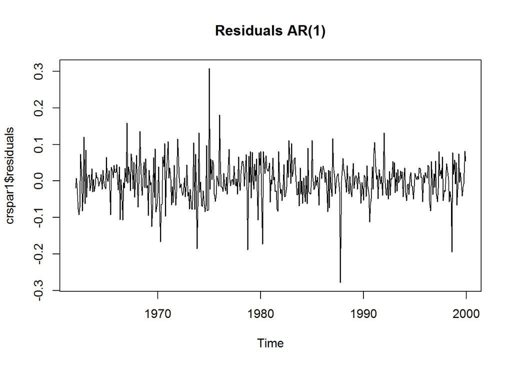

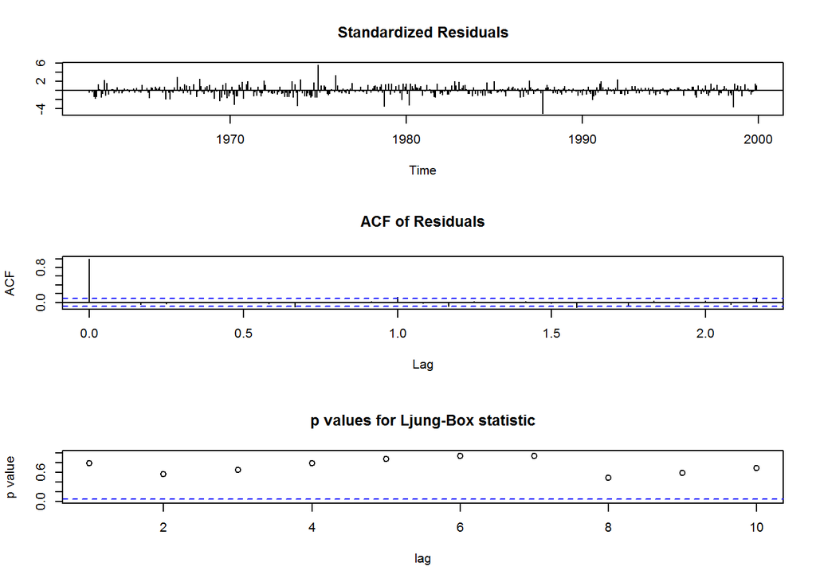

The residual plot looks a like white noise. This point is also proven with the ACF (auto correlation) plot were we see no correlation between residuals. To be sure we do a Box-Ljung test for the first 12 lags which yields a p-value of 0.26:

```
##
##  Box-Ljung test
##
## data:  crspar1$residuals
## X-squared = 14.615, df = 12, p-value = 0.2632
```

Thus, we don’t reject the null hypothesis and we conclude that the residuals are not correlated.

There is nothing else to model (just white noise) so the AR(1) is a good fit.

**1.d. Build an MA (1) model for the log returns and check the model**

Let’s now check a MA(1) model:

```
##
## Call:
## arima(x = crsp.ts, order = c(0, 0, 1))
##
## Coefficients:
##          ma1  intercept
##       0.2336     0.0122
## s.e.  0.0449     0.0031
##
## sigma^2 estimated as 0.002957:  log likelihood = 680.7,  aic = -1355.4
```

The model is **Xz = 0.0122 + at + 0.2336 at-1**.

Let’s review the diagnostic plots to see if we have a good model:

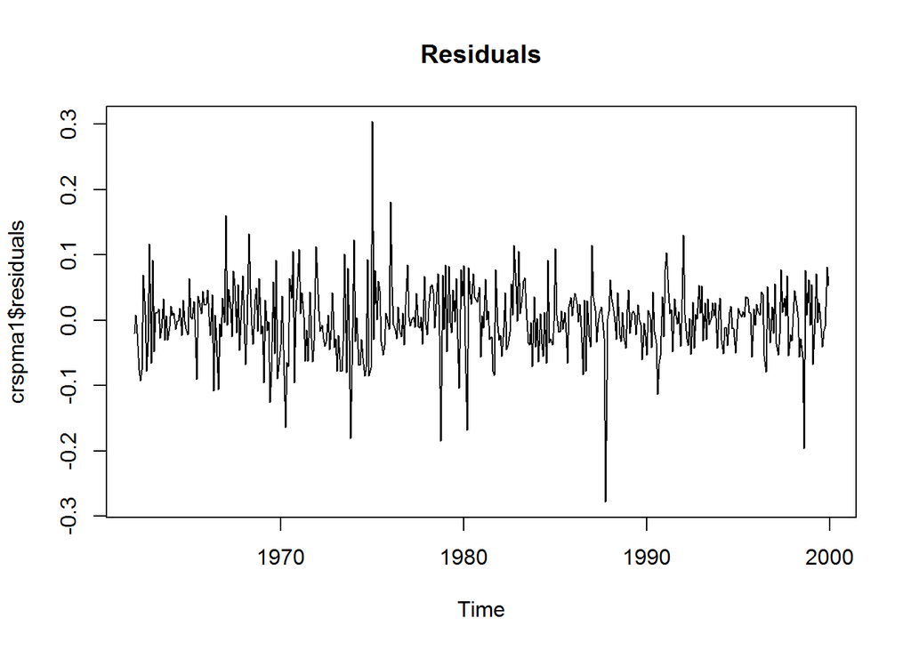

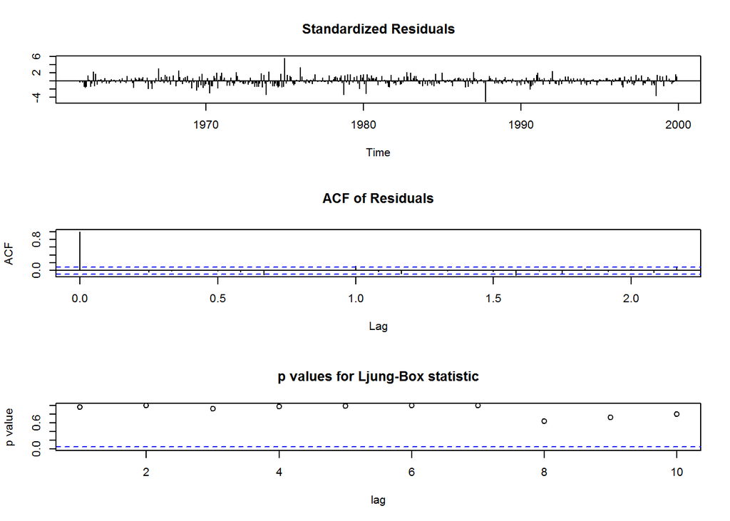

Once again, the residual plot looks a like white noise. There is no correlation on ACF plot. We do a Box-Ljung test (first 12 lags):

```
##
##  Box-Ljung test
##
## data:  crspma1$residuals
## X-squared = 12.865, df = 12, p-value = 0.379
```

The test yieds a p-value of 0.379, thus, we don’t reject the null hypothesis and we conclude that the residuals are not correlated.

AM(1) is a good fit because the residuals are white noise.

**1.e. Compute the 1-step to 3-step ahead forecasts for the AR(1) and MA(1) models built in parts c and d.**

Both the AR(1) model and the MV(1) appear to be adequate so they can be used to generate predictions for the next 3 months. First, let’s calculate and plot predictions with AR(1):

```
## $pred
##             Jan        Feb        Mar
## 2000 0.02851735 0.01587832 0.01304308
##
## $se
##             Jan        Feb        Mar
## 2000 0.05444968 0.05580285 0.05587008
```

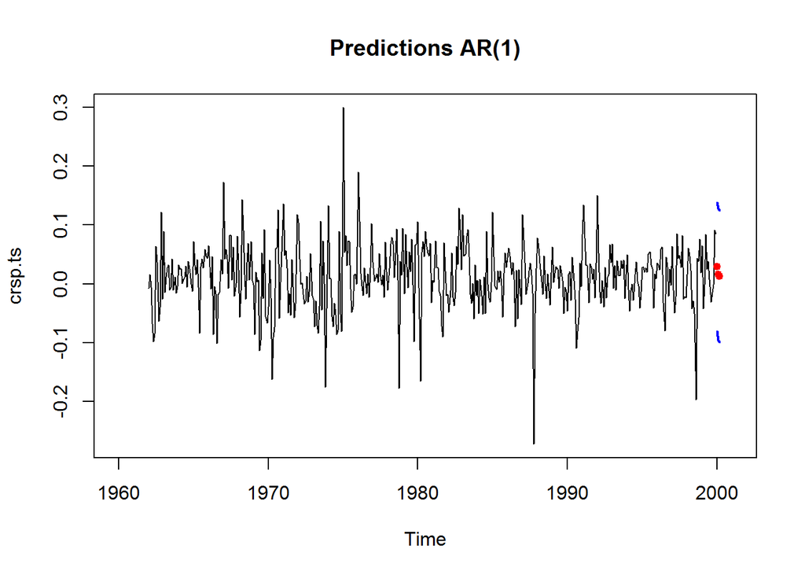

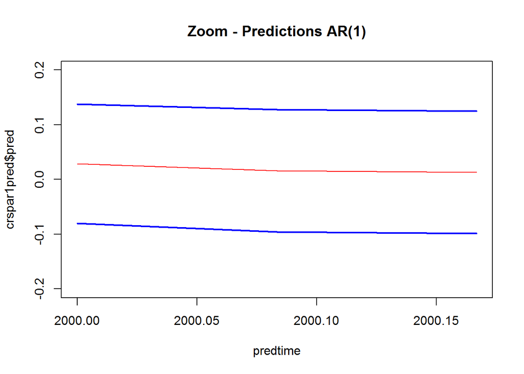

Now let’s predict with MV(1):

```
## $pred
##             Jan        Feb        Mar
## 2000 0.02472992 0.01220117 0.01220117
##
## $se
##             Jan        Feb        Mar
## 2000 0.05437958 0.05584413 0.05584413
```

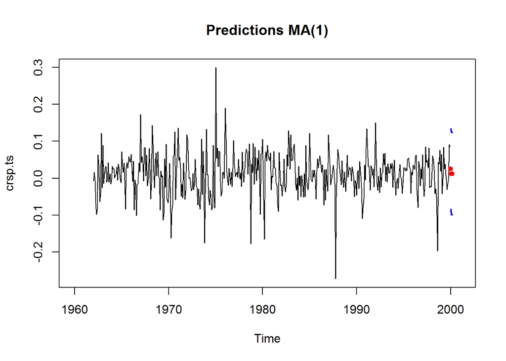

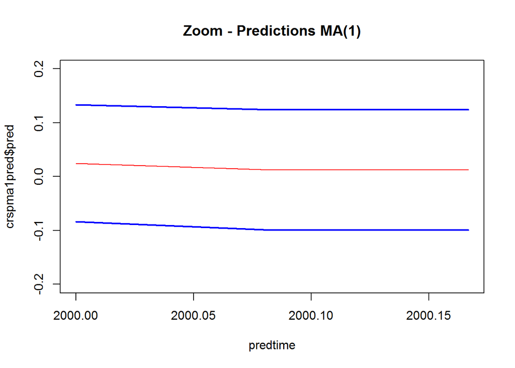

**1.f. Compare the fitted AR and MA models**

To compare both models we look at the AIC metric which takes into account model complexity. AM(1) has a lower AIC (-1355.4) that AR(1) (-1354.23) so we can say that MA(1) is a better fit for the data.

## Monthly simple returns of the decile 1, decile 5 and decile 10 of the NYSE/AMEX/NASDAQ based on market capitalization

Let’s plot the data for decile 1, decile 5 and decile 10:

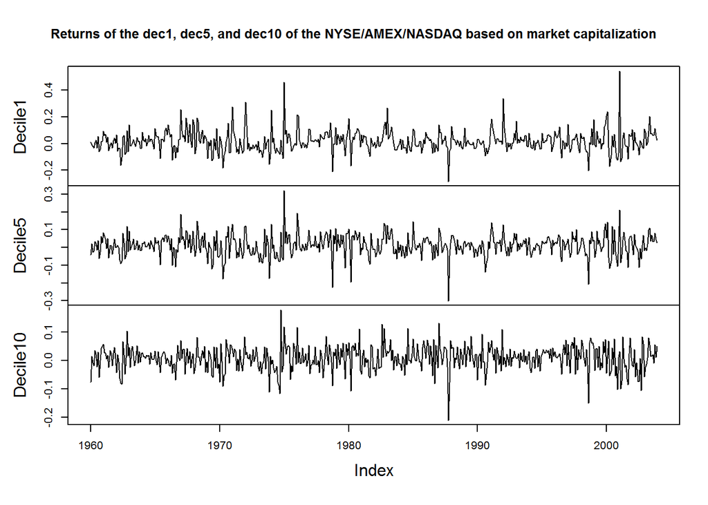

**2.a.For each return series, test the null hypothesis that the first 12 lags of the autocorrelations are zero at the 5% level. Draw your conclusion.**

First, let’s plot auto correlation for all 3 levels or dec (1, 5, and 10):

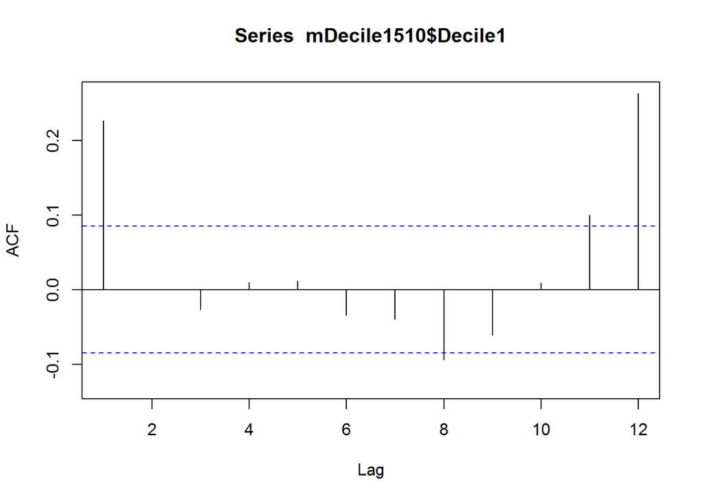

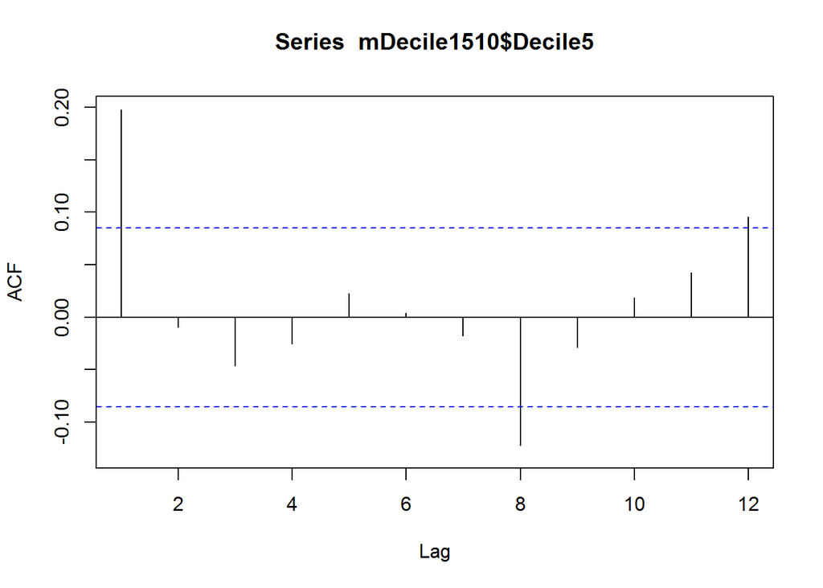

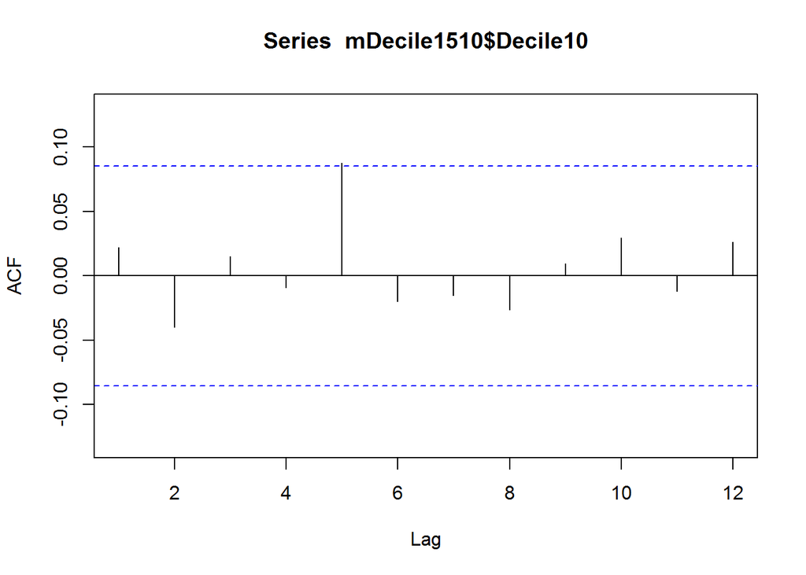

By inspecting the plots visually we can draw the following conclusions:

- dec1: There is significant correlation at lag 1 (next month) and lag 12 (same month next year).
- dec5: Significant correlation at lag 1. Other significant correlations are small and can be due to luck.
- dec10: No significant correlation. Possible white noise.

Now, let’s test if there is significant correlation for the first 12 lags at 5% level using the Box-Ljung test:

```
##
##  Box-Ljung test
##
## data:  mDecile1510$Decile1
## X-squared = 78.781, df = 12, p-value = 7.045e-12
```

```
##
##  Box-Ljung test
##
## data:  mDecile1510$Decile5
## X-squared = 37.289, df = 12, p-value = 0.0002005
```

```
##
##  Box-Ljung test
##
## data:  mDecile1510$Decile10
## X-squared = 7.0184, df = 12, p-value = 0.8564
```

As we suspected, for dec1 and dec5 we reject the null hypothesis at 5% and we conclude there is correlation for the first 12 lags. For dec10 we don’t reject the null hypothesis, there is no correlation.

**2.b.Build an AR and an MA model for the series Decile 5.**

We are going to focus on dec5 data. As we’ve seen above there is correlation at least at lag 1. Let’s plot the data again:

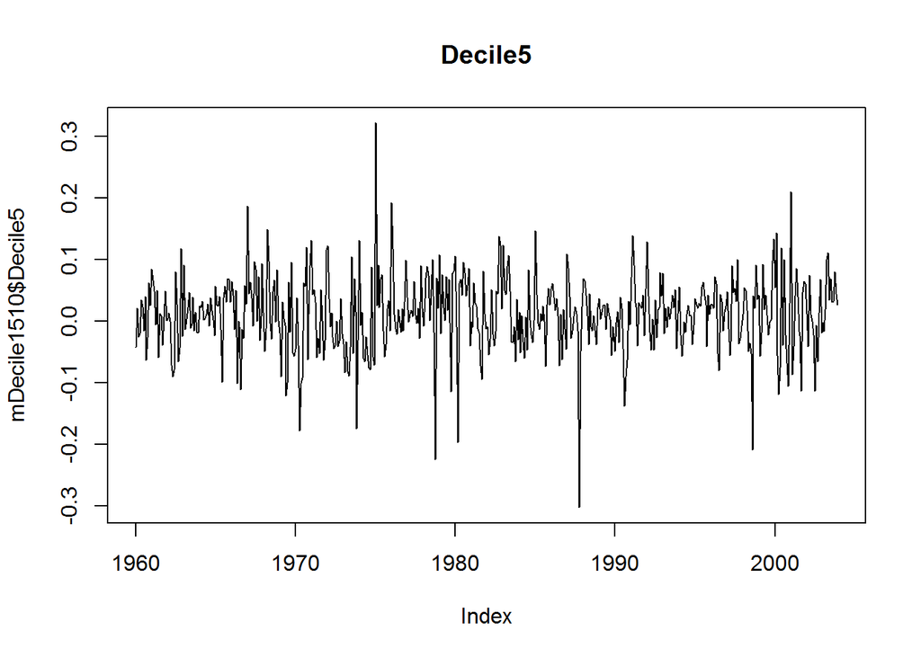

Mean and variance seem constant so we conclude we have a weakly stationary time series.

Let’s also check summary statistics:

```
##      Index      mDecile1510$Decile5
##  Min.   :1960   Min.   :-0.30210
##  1st Qu.:1971   1st Qu.:-0.02182
##  Median :1982   Median : 0.01293
##  Mean   :1982   Mean   : 0.01137
##  3rd Qu.:1993   3rd Qu.: 0.04435
##  Max.   :2004   Max.   : 0.32119
```

```
##      Start Size       Mean Standard.Deviation   Skewness Excess.Kurtosis
## 1 Jan 1960  528 0.01136805         0.06051162 -0.2055793        3.128584
##   Minimum Maximum
## 1 -0.3021 0.32119
```

Mean doesn’t equal 0 but, do we have enough evidence to say is different that 0? Let t-test for null hypothesis mean=0:

```
## [1] 7.914599e-06
```

The p-value is very small so we reject the null hypothesis and conclude the mean is not 0.

In order to select *p* for our AR(p) model we can use several techniques. Here we will use `ar` function in R which will select the appropriate *p* based on AIC results for each model:

```
##
## Call:
## ar(x = mDecile1510$Decile5, method = "mle")
##
## Coefficients:
##      1
## 0.1975
##
## Order selected 1  sigma^2 estimated as  0.003512
```

The model selected is AR(1) which matches our believe after inspecting auto correlation plot:

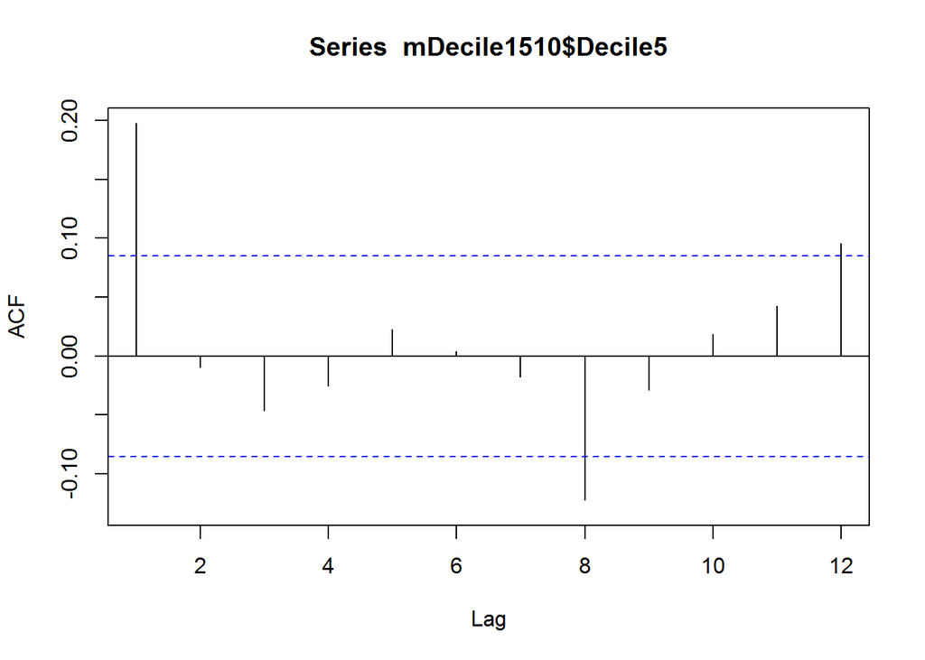

```
##
## Call:
## arima(x = mDecile1510$Decile5, order = c(1, 0, 0))
##
## Coefficients:
##          ar1  intercept
##       0.1975     0.0114
## s.e.  0.0426     0.0032
##
## sigma^2 estimated as 0.003512:  log likelihood = 742.8,  aic = -1479.6
```

Thus the model is **xt - 0.1975 xt-1 = 0.0114(1-0.1975) + at**

Let’s check diagnostic plots to see if it’s a good fit:

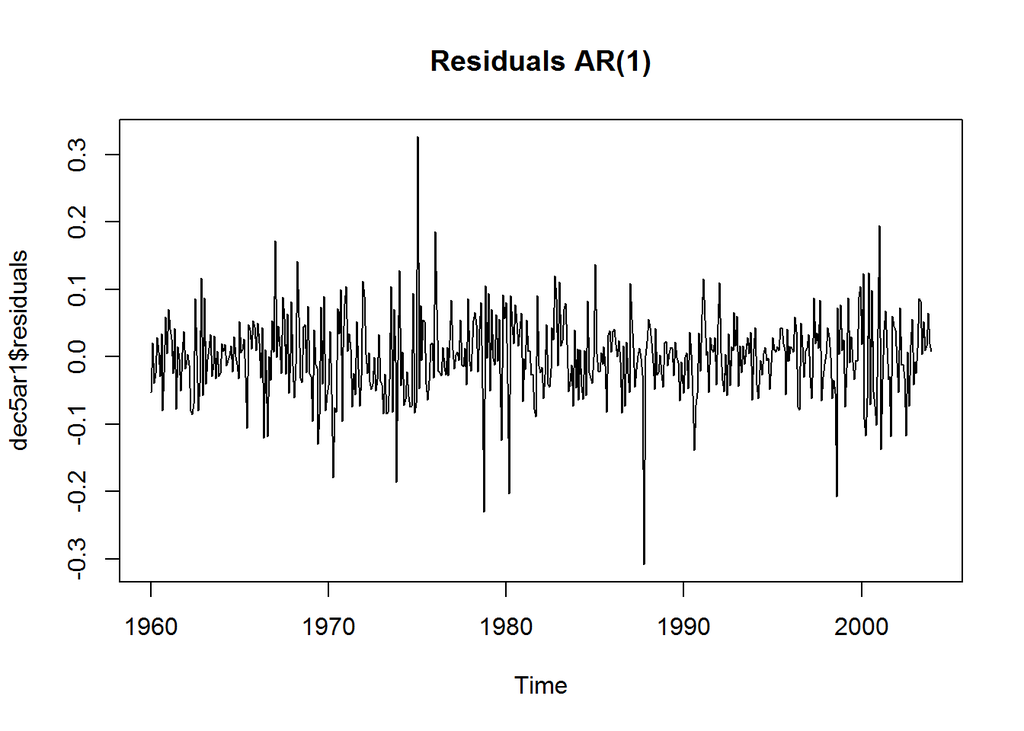

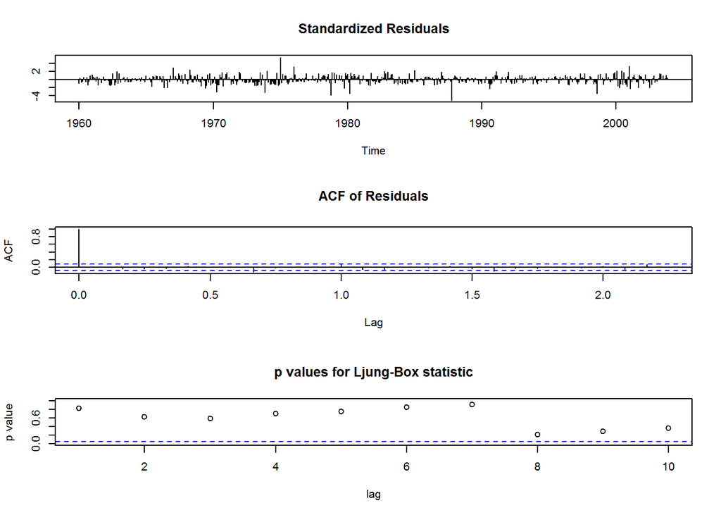

Residual plot looks like white noise (no correlation). To prove it we run a Box-Ljung test for first 12 lags:

```
##
##  Box-Ljung test
##
## data:  dec5ar1$residuals
## X-squared = 16.96, df = 12, p-value = 0.1511
```

P-value is above significance level (5%) so we conclude the residuals are independent for the first 12 lags. Our model is a good fit to the data and there is nothing else to model as the residuals are white noise.

Now we are going to fit a MV(q) model. To select *q* we can inspect again auto correlation plot. It seems *q* equal to 1 can be a good fit for the data. We can confirm this by using R `auto.arima` which will compare models using AIC. We are only interested in the entries with non-zero mean and the form ARIMA(0,0,q).

```
##
##  ARIMA(0,0,0) with zero mean     : -1444.21
##  ARIMA(0,0,0) with non-zero mean : -1460.557
##  ARIMA(0,0,1) with zero mean     : -1469.558
##  ARIMA(0,0,1) with non-zero mean : -1480.543
##  ARIMA(0,0,2) with zero mean     : -1468.075
##  ARIMA(0,0,2) with non-zero mean : -1478.562
##  ARIMA(0,0,3) with zero mean     : -1466.136
##  ARIMA(0,0,3) with non-zero mean : -1477.221
##  ARIMA(1,0,0) with zero mean     : -1469.166
##  ARIMA(1,0,0) with non-zero mean : -1479.391
##  ARIMA(1,0,1) with zero mean     : -1467.599
##  ARIMA(1,0,1) with non-zero mean : -1478.508
##  ARIMA(1,0,2) with zero mean     : -1465.899
##  ARIMA(1,0,2) with non-zero mean : -1476.701
##  ARIMA(1,0,3) with zero mean     : -1464.072
##  ARIMA(1,0,3) with non-zero mean : -1475.44
##  ARIMA(2,0,0) with zero mean     : -1466.816
##  ARIMA(2,0,0) with non-zero mean : -1477.863
##  ARIMA(2,0,1) with zero mean     : -1464.827
##  ARIMA(2,0,1) with non-zero mean : -1476.166
##  ARIMA(2,0,2) with zero mean     : -1463.04
##  ARIMA(2,0,2) with non-zero mean : -1474.408
##  ARIMA(2,0,3) with zero mean     : -1462.197
##  ARIMA(2,0,3) with non-zero mean : Inf
##  ARIMA(3,0,0) with zero mean     : -1464.163
##  ARIMA(3,0,0) with non-zero mean : -1476.046
##  ARIMA(3,0,1) with zero mean     : -1462.154
##  ARIMA(3,0,1) with non-zero mean : -1474.128
##  ARIMA(3,0,2) with zero mean     : -1464.864
##  ARIMA(3,0,2) with non-zero mean : -1476.948
```

ARIMA(0,0,1) has the lower AIC which matches what we saw on the auto correlation plot. Thus, we use MA(1):

```
##
## Call:
## arima(x = mDecile1510$Decile5, order = c(0, 0, 1))
##
## Coefficients:
##          ma1  intercept
##       0.2050     0.0114
## s.e.  0.0421     0.0031
##
## sigma^2 estimated as 0.003505:  log likelihood = 743.29,  aic = -1480.58
```

The model is **Xz = 0.0114 + at + 0.2050 at-1**.

Let’s check diagnostic plots to see if it’s a good fit:

[figure not shown]

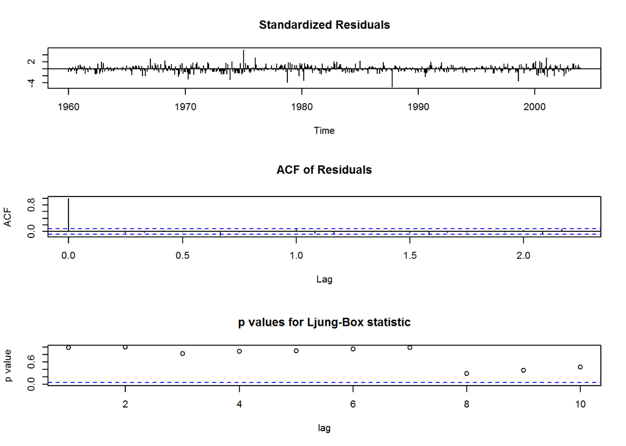

Residual plot looks like white noise (no correlation). To prove it we run a Box-Ljung test for first 12 lags:

```
##
##  Box-Ljung test
##
## data:  dec5ma1$residuals
## X-squared = 15.589, df = 12, p-value = 0.2108
```

P-value is above significance level (5%) so we conclude the residuals are independent for the first 12 lags. Again, our model is a good fit to the data.

**2.c.Use the AR and MA models built to produce 1-step to 3-step ahead forecasts of the series**

Now that we know our models are a good fit let’s calculate predictions for the next 3 steps. First we use AR(1) to predict and plot the results:

```
## $pred
##             Jan        Feb        Mar
## 2004 0.01430997 0.01193451 0.01146544
##
## $se
##             Jan        Feb        Mar
## 2004 0.05926144 0.06040572 0.06044990
```

[figure not shown]

[figure not shown]

Now we do the same with MA(1):

```
## $pred
##             Jan        Feb        Mar
## 2004 0.01359002 0.01135644 0.01135644
##
## $se
##             Jan        Feb        Mar
## 2004 0.05920642 0.06043824 0.06043824
```

[figure not shown]

[figure not shown]

**2.d.Compare the AR and MA models you fit to determine which you feel is better and why.**

MA(1) has lower AIC (-1480.58) than AR(1) (-1479.6) so we can say that is a better fit.